# Random effect models

## 0.1 https://stat.ethz.ch/~meier/teaching/anova/random-and-mixed-effects-models.html#one-way-anova

A ﬁxed effect is an unknown constant that we try to estimate from the data.

In contrast, a random effect is a random variable. It does not make sense to estimate a random effect; instead, we try to estimate the parameters that describe the distribution of this random effect.

For example, Consider an experiment to investigate the effect of several drug treatments on a sample of patients.

1. Typically, we are interested in speciﬁc drug treatments and so we would treat the drug effects as ﬁxed.
2. However, it makes most sense to treat the patient effects as random. It is often reasonable to treat the patients as being randomly selected from a larger collection of patients whose characteristics we would like to estimate.
3. Furthermore, we are not particularly interested in these speciﬁc patients, but in the whole population of patients.

In fixed effect models, the categorical variabels are well-defined. In some desings, the category is `subject`. In the simplest example, we may observe repeated measuements from subjects. In this case, the group effect can be regarded as random since we take a sample a subset from an entire population.

# 1 Random effect model with one factor

> Ex : Sodium content in beer - How much sodium is there in North American beer? How much does this vary by brand?

Suppose that we take 6 brands of beer and for each brand we record 8 bottles. Here, the group effect is brand which can be regarded as random because there are more than 6 brands in North America.

## 1.1 The model

$$y_{ij} = \mu + \alpha_i + \epsilon_{ij},~i=1,2,\ldots,a,~j=1,2,\ldots,n$$

$\epsilon_{ij}\sim N(0,\sigma^2)$ and $\alpha_i \sim N(0,\sigma_\alpha^2)$. We are interested in if the sodium level varies by brand, that is, $\sigma_\alpha^2 = 0$?

Note that, under this model, the observations are no longer independent.

$$Corr(y_{ij},y_{ik}) = \frac{\sigma_\alpha^2}{\sigma_\alpha^2 + \sigma^2}$$

This is called the intraclass correlation. If $\sigma_\alpha^2 = 0$, this becomes zero and if the variation between the levels is much larger than that within the levels, the value will approach 1.

In the random effect model, decomposition of variations can be also made.

$$SST=SSA+SSE$$

And, it can be shown that

$$E(SSE)=a(n-1)\sigma^2,~E(SSA)=(a-1)(n\sigma_\alpha^2 + \sigma^2)$$

This suggests that

$$\hat\sigma^2 = SSE/(a(n-1)) = MSE , ~~ \hat\sigma_\alpha^2 = (MSA - MSE ) /n$$

This does have disadvantages. One of them is that the estimate for $\sigma_\alpha^2$ may be negative. To avoid this, we may employ the maximum likelihood estimation.

## 1.2 Example : Weight of beef animals by sire

There are five different sires. In each group, Birth weight of 8 male calves were recorded. We want to find out what part of the total variation is due to variation between different sires.

```r
weight <- c(61, 100,  56, 113,  99, 103,  75,  62,  ## sire 1
            75, 102,  95, 103,  98, 115,  98,  94,  ## sire 2
            58,  60,  60,  57,  57,  59,  54, 100,  ## sire 3
            57,  56,  67,  59,  58, 121, 101, 101,  ## sire 4
            59,  46, 120, 115, 115,  93, 105,  75)  ## sire 5
sire    <- factor(rep(1:5, each = 8))
animals <- data.frame(weight, sire)
str(animals)
```

```
## 'data.frame':    40 obs. of  2 variables:
##  $ weight: num  61 100 56 113 99 103 75 62 75 102 ...
##  $ sire  : Factor w/ 5 levels "1","2","3","4",..: 1 1 1 1 1 1 1 1 2 2 ...
```

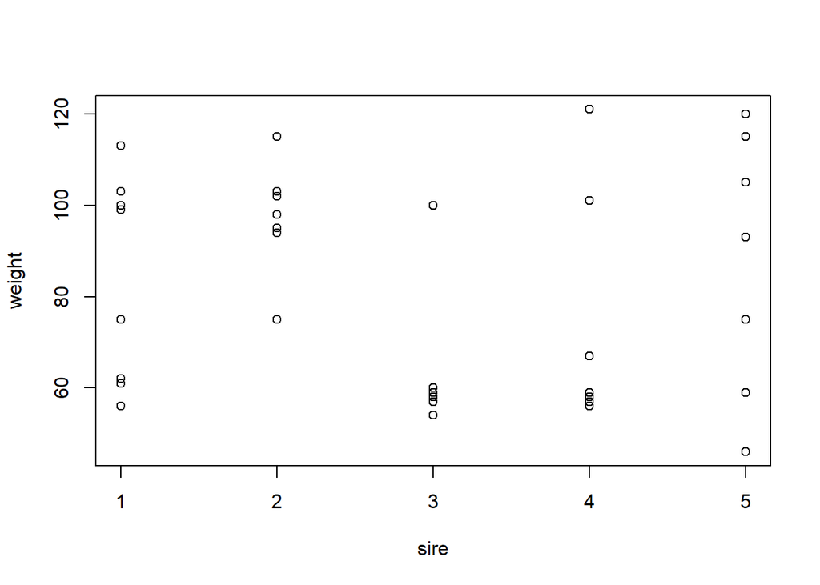

```r
stripchart(weight ~ sire, vertical = TRUE, pch = 1, xlab = "sire", data = animals)
```

Note that sires are random effects here. Let us fit a one factor random effect model.

```r
library(lme4)
fit.sire <- lmer(weight ~ (1 | sire), data = animals)
summary(fit.sire)
```

```
## Linear mixed model fit by REML ['lmerMod']
## Formula: weight ~ (1 | sire)
##    Data: animals
##
## REML criterion at convergence: 358.2
##
## Scaled residuals:
##     Min      1Q  Median      3Q     Max
## -1.9593 -0.7459 -0.1581  0.8143  1.9421
##
## Random effects:
##  Groups   Name        Variance Std.Dev.
##  sire     (Intercept) 116.7    10.81
##  Residual             463.8    21.54
## Number of obs: 40, groups:  sire, 5
##
## Fixed effects:
##             Estimate Std. Error t value
## (Intercept)   82.550      5.911   13.96
```

```r
confint(fit.sire, oldNames = FALSE)  # approximate confidence interval
```

```
## Computing profile confidence intervals ...
```

```
##                        2.5 %   97.5 %
## sd_(Intercept)|sire  0.00000 24.61580
## sigma               17.32943 27.76544
## (Intercept)         69.83802 95.26197
```

# 2 Random effect model with two factor

A manufacturer was developing a new spectrophotometer for medical labs. A critical issue is consistency of measurements from day to day among different machines. 4 machines were randomly selected from the production process and tested on 4 randomly selected days. Per day 8 serum samples were randomly assigned to the 4 machines (2 samples per machine). Response is the triglyceride level [mg/dl] of a sample.

```r
##     machine 1     machine 2     machine 3     machine 4
y <- c(142.3, 144.0, 148.6, 146.9, 142.9, 147.4, 133.8, 133.2, ## day 1
       134.9, 146.3, 145.2, 146.3, 125.9, 127.6, 108.9, 107.5, ## day 2
       148.6, 156.5, 148.6, 153.1, 135.5, 138.9, 132.1, 149.7, ## day 3
       152.0, 151.4, 149.7, 152.0, 142.9, 142.3, 141.7, 141.2) ## day 4

trigly <- data.frame(y = y, day = factor(rep(1:4, each = 8)),
                     machine = factor(rep(rep(1:4, each = 2), 2)))
str(trigly)
```

```
## 'data.frame':    32 obs. of  3 variables:
##  $ y      : num  142 144 149 147 143 ...
##  $ day    : Factor w/ 4 levels "1","2","3","4": 1 1 1 1 1 1 1 1 2 2 ...
##  $ machine: Factor w/ 4 levels "1","2","3","4": 1 1 2 2 3 3 4 4 1 1 ...
```

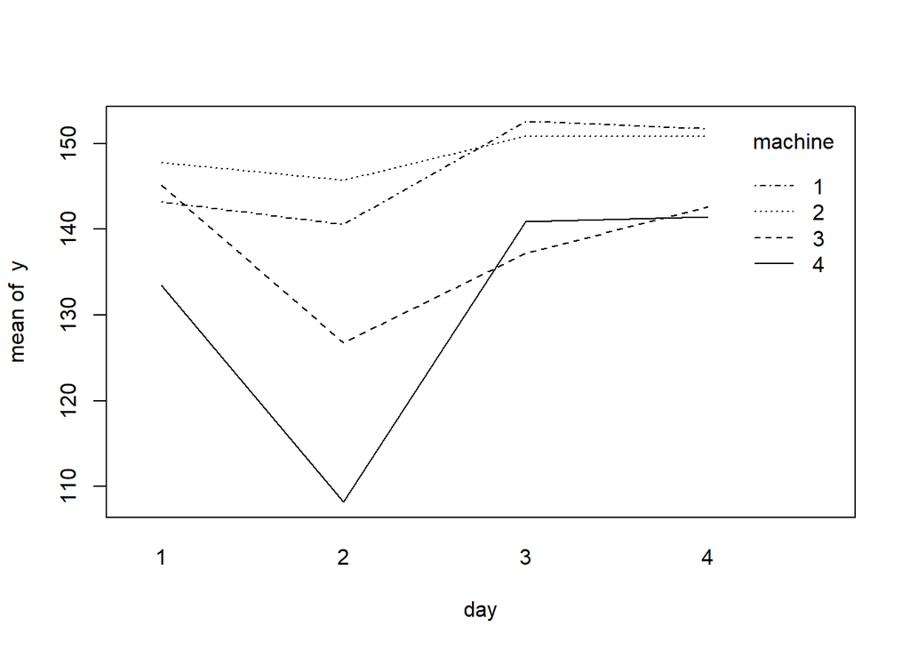

```r
with(trigly, interaction.plot(x.factor = day, trace.factor = machine, response = y))
```

We fit a two factor random effect model.

```r
fit.trigly <- lmer(y ~ (1 | day) + (1 | machine) + (1 | machine:day), data = trigly)
summary(fit.trigly)
```

```
## Linear mixed model fit by REML ['lmerMod']
## Formula: y ~ (1 | day) + (1 | machine) + (1 | machine:day)
##    Data: trigly
##
## REML criterion at convergence: 215
##
## Scaled residuals:
##     Min      1Q  Median      3Q     Max
## -1.8426 -0.3558  0.0348  0.2072  2.3178
##
## Random effects:
##  Groups      Name        Variance Std.Dev.
##  machine:day (Intercept) 34.69    5.890
##  machine     (Intercept) 57.77    7.601
##  day         (Intercept) 44.76    6.690
##  Residual                17.90    4.230
## Number of obs: 32, groups:  machine:day, 16; machine, 4; day, 4
##
## Fixed effects:
##             Estimate Std. Error t value
## (Intercept)  141.184      5.325   26.51
## convergence code: 0
## Model failed to converge with max|grad| = 0.002216 (tol = 0.002, component 1)
```

```r
confint(fit.trigly, oldNames = FALSE)  # approximate confidence interval
```

```
## Computing profile confidence intervals ...
```

```
##                                 2.5 %     97.5 %
## sd_(Intercept)|machine:day   2.956021  11.296840
## sd_(Intercept)|machine       0.000000  18.481628
## sd_(Intercept)|day           0.000000  16.968920
## sigma                        3.100604   6.257749
## (Intercept)                129.938480 152.430210
```

We see that the largest contribution to the variance is variability between different machines.

# 3 Random effect model with nested structure

The strength of a chemical paste product was measured for a total of 60 samples coming from 10 randomly selected delivery batches each containing 3 randomly selected casks. Hence, two samples were taken from each cask. We want to check what part of the variability of strength is due to batch and cask.

```r
data("Pastes", package = "lme4")
str(Pastes)
```

```
## 'data.frame':    60 obs. of  4 variables:
##  $ strength: num  62.8 62.6 60.1 62.3 62.7 63.1 60 61.4 57.5 56.9 ...
##  $ batch   : Factor w/ 10 levels "A","B","C","D",..: 1 1 1 1 1 1 2 2 2 2 ...
##  $ cask    : Factor w/ 3 levels "a","b","c": 1 1 2 2 3 3 1 1 2 2 ...
##  $ sample  : Factor w/ 30 levels "A:a","A:b","A:c",..: 1 1 2 2 3 3 4 4 5 5 ...
```

Note that cask 1 in batch 1 has nothing to do with cask 1 in batch 2 and so on. The “1” of cask has a different meaning for every batch. Hence, cask and batch are not crossed. We say cask is nested in batch.

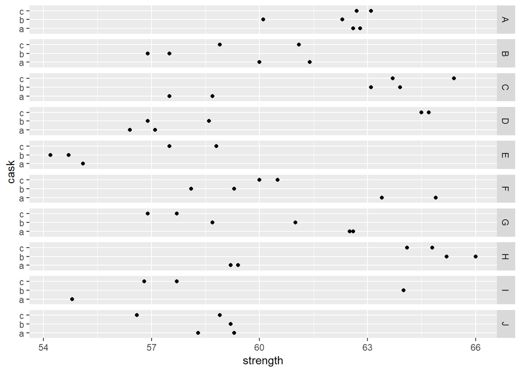

```r
library(ggplot2)
ggplot(Pastes, aes(y = cask, x = strength)) + geom_point() + facet_grid(batch ~ .)
```

The batch effect doesn’t seem to be very pronounced. On the other side, casks within the same batch can be substantially different.

```r
fit.paste <- lmer(strength ~ (1 | batch/cask), data = Pastes)
summary(fit.paste)
```

```
## Linear mixed model fit by REML ['lmerMod']
## Formula: strength ~ (1 | batch/cask)
##    Data: Pastes
##
## REML criterion at convergence: 247
##
## Scaled residuals:
##     Min      1Q  Median      3Q     Max
## -1.4798 -0.5156  0.0095  0.4720  1.3897
##
## Random effects:
##  Groups     Name        Variance Std.Dev.
##  cask:batch (Intercept) 8.434    2.9041
##  batch      (Intercept) 1.657    1.2874
##  Residual               0.678    0.8234
## Number of obs: 60, groups:  cask:batch, 30; batch, 10
##
## Fixed effects:
##             Estimate Std. Error t value
## (Intercept)  60.0533     0.6769   88.72
```

```r
confint(fit.paste, oldNames = FALSE)  # approximate confidence interval
```

```
## Computing profile confidence intervals ...
```

```
##                                2.5 %    97.5 %
## sd_(Intercept)|cask:batch  2.1579343  4.053499
## sd_(Intercept)|batch       0.0000000  2.946591
## sigma                      0.6520234  1.085448
## (Intercept)               58.6636504 61.443016
```

We see that most variation is in fact due to cask within batch.

# 4 Mixed effect model

In practice we often encounter models which contain both random and fixed effects. We call them mixed effects models.

Six workers were chosen randomly among the employees of a factory to operate each machine three times. The response is an overall productivity score taking into account the number and quality of components produced.”

```r
data("Machines", package = "nlme")
## technical detail for nicer output:
Machines[, "Worker"] <- factor(Machines[, "Worker"], levels = 1:6, ordered = FALSE)
str(Machines, give.attr = FALSE) ## give.attr in order to shorten output
```

```
## Classes 'nffGroupedData', 'nfGroupedData', 'groupedData' and 'data.frame':   54 obs. of  3 variables:
##  $ Worker : Factor w/ 6 levels "1","2","3","4",..: 1 1 1 2 2 2 3 3 3 4 ...
##  $ Machine: Factor w/ 3 levels "A","B","C": 1 1 1 1 1 1 1 1 1 1 ...
##  $ score  : num  52 52.8 53.1 51.8 52.8 53.1 60 60.2 58.4 51.1 ...
```

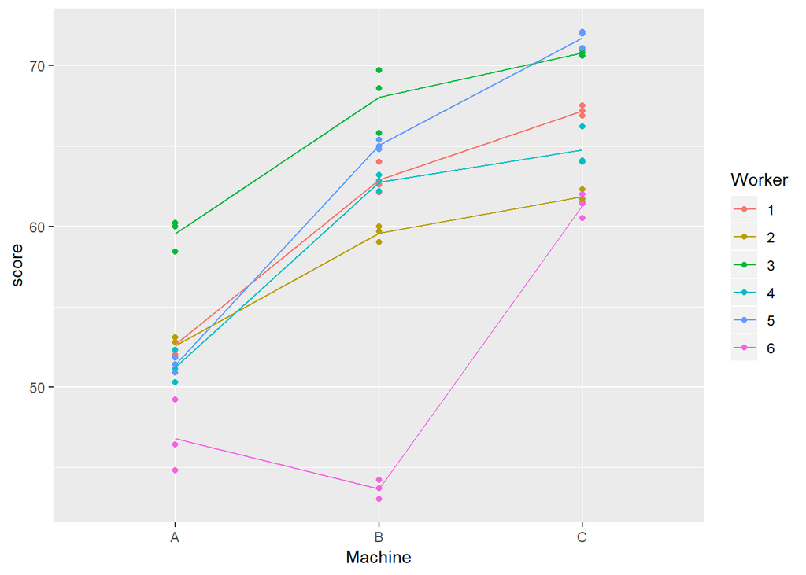

```r
ggplot(Machines, aes(x = Machine, y = score, group = Worker, col = Worker)) +
  geom_point() + stat_summary(fun.y = mean, geom = "line")
```

We consider the machince as fixed and the employees as random.

```r
fit <- lmer(score ~ Machine + (1 | Worker) + (1 | Worker:Machine), data = Machines)
summary(fit)
```

```
## Linear mixed model fit by REML ['lmerMod']
## Formula: score ~ Machine + (1 | Worker) + (1 | Worker:Machine)
##    Data: Machines
##
## REML criterion at convergence: 215.7
##
## Scaled residuals:
##      Min       1Q   Median       3Q      Max
## -2.26959 -0.54847 -0.01071  0.43937  2.54006
##
## Random effects:
##  Groups         Name        Variance Std.Dev.
##  Worker:Machine (Intercept) 13.9095  3.7295
##  Worker         (Intercept) 22.8584  4.7811
##  Residual                    0.9246  0.9616
## Number of obs: 54, groups:  Worker:Machine, 18; Worker, 6
##
## Fixed effects:
##             Estimate Std. Error t value
## (Intercept)   52.356      2.486  21.062
## MachineB       7.967      2.177   3.660
## MachineC      13.917      2.177   6.393
##
## Correlation of Fixed Effects:
##          (Intr) MachnB
## MachineB -0.438
## MachineC -0.438  0.500
```

To test the fiexd effect, another package is introduced.

```r
options(contrasts = c("contr.treatment", "contr.poly"))
library(lmerTest)
fit <- lmer(score ~ Machine + (1 | Worker) + (1 | Worker:Machine), data = Machines)
anova(fit)
```

```
## Type III Analysis of Variance Table with Satterthwaite's method
##         Sum Sq Mean Sq NumDF DenDF F value    Pr(>F)
## Machine 38.051  19.025     2    10  20.576 0.0002855 ***
## ---
## Signif. codes:  0 '***' 0.001 '**' 0.01 '*' 0.05 '.' 0.1 ' ' 1
```

```r
confint(fit, oldNames = FALSE)
```

```
## Computing profile confidence intervals ...
```

```
##                                    2.5 %    97.5 %
## sd_(Intercept)|Worker:Machine  2.3528037  5.431503
## sd_(Intercept)|Worker          1.9514584  9.410583
## sigma                          0.7759506  1.234965
## (Intercept)                   47.3951611 57.315949
## MachineB                       3.7380904 12.195243
## MachineC                       9.6880904 18.145243
```